```python
import numpy as np
import matplotlib.pyplot as plt
```

# Exercice Numpy

## 1. Array creation

- Create a 1D array with values from 0 to 10 and in steps of 0.1. Check the shape of the array:

```python
xarray = np.arange(0,10,0.1)
xarray.shape
```

```
(100,)
```

1.2. Create an array of normally distributed numbers with mean $\mu=0$ and standard deviation $\sigma=0.5$. It should have 20 rows and as many columns as there are elements in `xarray`. Call it `normal_array`:

```python
normal_array = np.random.normal(0,0.5,(20, xarray.shape[0]))
```

- Check the type of `normal_array`:

```python
normal_array.dtype
```

```
dtype('float64')
```

## 2. Array mathematics

```python
yarray = 5*np.cos(xarray)*np.exp(-0.1*xarray)
```

```python
array_abs = np.abs(yarray)
```

- 2.2 Create a boolan array (logical array) where all positions $>0.3$ in `array_abs` are `True` and the others `False`

```python
array_bool = array_abs > 0.3
```

```python
array_min = normal_array.std(axis = 1)
array_min.shape
```

```
(20,)
```

```python
array_min
```

```
array([0.54167658, 0.51651789, 0.4832876 , 0.54537271, 0.50834276,
       0.47623427, 0.44677832, 0.47841273, 0.50255308, 0.50656681,
       0.47822978, 0.52051232, 0.55511136, 0.46977863, 0.57914545,
       0.47393849, 0.52705922, 0.43786828, 0.55795931, 0.45476456])
```

## 3. Plotting

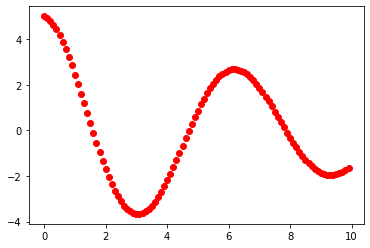

```python
plt.plot(xarray, yarray,'ro')
```

- Try to change the color of the plot to red and to have markers on top of the line as squares:

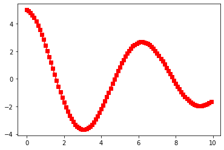

```python
plt.plot(xarray, yarray, '-sr')
```

- Plot the `normal_array` as an imagage and change the colormap to 'gray':

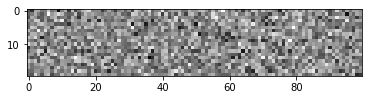

```python
plt.imshow(normal_array, cmap = 'gray')
```

- Assemble the two above plots in a figure with one row and two columns grid:

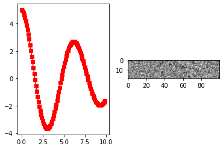

```python
fig, ax = plt.subplots(1,2)
ax[0].plot(xarray, yarray, '-sr')
ax[1].imshow(normal_array, cmap = 'gray')
```

## 4. Indexing

- Create new arrays where you select every second element from xarray and yarray. Plot them on top of `xarray` and `yarray`.

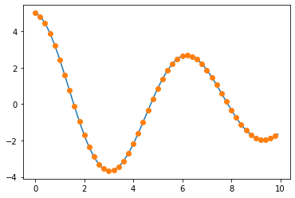

```python
xarray2 = xarray[::2]
yarray2 = yarray[::2]

plt.plot(xarray, yarray)
plt.plot(xarray2, yarray2,'o')
```

- Select all values of `yarray` that are larger than 0. Plot those on top of the regular `xarray` and `yarray`plot.

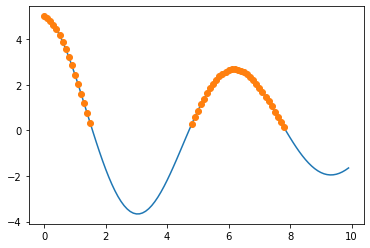

```python
plt.plot(xarray, yarray)
plt.plot(xarray[yarray>0], yarray[yarray>0],'o')
```

- Flip the order of `xarray` use it to plot `yarray`:

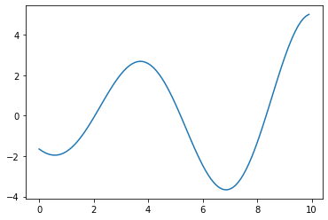

```python
flipped_array = np.flipud(xarray)
plt.plot(flipped_array, yarray)
```

## 5. Combining arrays

- Create an array filled with ones with the same shape as `normal_array`. Concatenate it to `normal_array` along the first dimensions and plot the result:

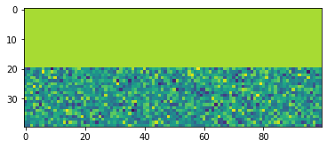

```python
ones_array = np.ones(normal_array.shape)
concatenated = np.concatenate([ones_array, normal_array])

plt.imshow(concatenated);
```

- `yarray` represents a signal. Each line of `normal_array` represents a possible random noise for that signal. Using broadcasting, try to create an array of noisy versions of `yarray` using `normal_array`. Finally, plot it:

The last dimensions of both arrays are matching. We can therefore simply added the two arrays, and `yarray` will simply be "replicated" as many times as needed:

```python
yarray_noise = yarray + normal_array
```

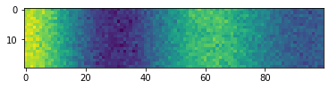

```python
plt.imshow(yarray_noise)
```